# Análisis exploratorio de la encuesta inicial

Kenneth Roy Cabrera Torres

Viernes, 26 de marzo de 2021

## Lectura de la base de datos.

## Depuración y adecuación de la base de datos.

```
## 'data.frame':    87 obs. of  44 variables:
##  $ Respuesta                                                                  : int  2439 2459 2517 2448 2499 2505 2503 2515 2484 2454 ...
##  $ Enviado.el.                                                                : chr  "26/02/2021 09:43:10" "26/02/2021 09:47:45" "26/02/2021 09:56:39" "26/02/2021 09:55:11" ...
##  $ Q01_Genero                                                                 : chr  "1 : Masculino" "1 : Masculino" "1 : Masculino" "1 : Masculino" ...
##  $ Q02_FechaNac                                                               : chr  "1997-01-17" "1998-07-26" "1996-09-05" "1997-01-20" ...
##  $ Q03_Carrera                                                                : chr  "1 : Matemáticas" "2 : Ingeniería de sistemas e informática" "2 : Ingeniería de sistemas e informática" "2 : Ingeniería de sistemas e informática" ...
##  $ Q04_Semestre                                                               : num  7 5.3 7.7 6 7.6 4 8 7 3 5 ...
##  $ Q05_Saber11                                                                : int  420 347 270 325 430 0 380 73 380 300 ...
##  $ Q06_PercentilSaber11                                                       : num  3 90.9 75 70 85 0 80 5 70 60 ...
##  $ Q07_FechaSaber11                                                           : chr  "2014-08-26" "2015-08-02" "2013-04-13" "2014-08-14" ...
##  $ Q08_PAPA                                                                   : num  3.7 3.4 3.8 4.6 3.7 3.3 4.3 NA 3.8 4.2 ...
##  $ Q09_EnAreaMetropolitana                                                    : int  1 1 1 1 1 1 1 1 1 1 ...
##  $ Q10_Estrato                                                                : chr  "4 : 3" "3 : 2" "4 : 3" "4 : 3" ...
##  $ Q11_R                                                                      : int  1 1 0 1 1 1 1 1 1 1 ...
##  $ Q12_RStudio                                                                : int  1 1 1 1 1 1 1 1 1 1 ...
```

[output cut: 30 more lines]

```
## Rows: 87
## Columns: 44
## $ Respuesta                                                                   <int> ~
## $ Enviado.el.                                                                 <chr> ~
## $ Q01_Genero                                                                  <chr> ~
## $ Q02_FechaNac                                                                <chr> ~
## $ Q03_Carrera                                                                 <chr> ~
## $ Q04_Semestre                                                                <dbl> ~
## $ Q05_Saber11                                                                 <int> ~
## $ Q06_PercentilSaber11                                                        <dbl> ~
## $ Q07_FechaSaber11                                                            <chr> ~
## $ Q08_PAPA                                                                    <dbl> ~
## $ Q09_EnAreaMetropolitana                                                     <int> ~
## $ Q10_Estrato                                                                 <chr> ~
## $ Q11_R                                                                       <int> ~
```

[output cut: 31 more lines]

```
##    Respuesta    Enviado.el.         Q01_Genero        Q02_FechaNac
##  Min.   :2429   Length:87          Length:87          Length:87
##  1st Qu.:2450   Class :character   Class :character   Class :character
##  Median :2472   Mode  :character   Mode  :character   Mode  :character
##  Mean   :2472
##  3rd Qu.:2494
##  Max.   :2517
##
##  Q03_Carrera         Q04_Semestre    Q05_Saber11    Q06_PercentilSaber11
##  Length:87          Min.   :1.500   Min.   :  0.0   Min.   :  0.00
##  Class :character   1st Qu.:2.000   1st Qu.:298.5   1st Qu.: 74.50
##  Mode  :character   Median :3.000   Median :327.0   Median : 88.00
##                     Mean   :3.543   Mean   :322.0   Mean   : 82.78
##                     3rd Qu.:5.000   3rd Qu.:358.5   3rd Qu.: 96.50
##                     Max.   :8.000   Max.   :580.0   Max.   :260.00
##                     NA's   :1
##  Q07_FechaSaber11      Q08_PAPA      Q09_EnAreaMetropolitana Q10_Estrato
##  Length:87          Min.   : 3.000   Min.   :0.0000          Length:87
##  Class :character   1st Qu.: 3.800   1st Qu.:0.0000          Class :character
##  Mode  :character   Median : 4.100   Median :1.0000          Mode  :character
##                     Mean   : 4.562   Mean   :0.7241
##                     3rd Qu.: 4.300   3rd Qu.:1.0000
##                     Max.   :45.000   Max.   :1.0000
##                     NA's   :9
##      Q11_R         Q12_RStudio     Q13_NoRoRStudio
##  Min.   :0.0000   Min.   :0.0000   Length:87
##  1st Qu.:1.0000   1st Qu.:1.0000   Class :character
##  Median :1.0000   Median :1.0000   Mode  :character
##  Mean   :0.9195   Mean   :0.8736
##  3rd Qu.:1.0000   3rd Qu.:1.0000
##  Max.   :1.0000   Max.   :1.0000
##
##  Q14_RecursosInformaticos..Internet.de.cable.propio
##  Min.   :0.0000
##  1st Qu.:0.0000
##  Median :0.0000
##  Mean   :0.4483
##  3rd Qu.:1.0000
##  Max.   :1.0000
##
```

[output cut: 121 more lines]

```
##  Min.   :0.0000                   Min.   :0.0000
##  1st Qu.:1.0000                   1st Qu.:0.0000
##  Median :1.0000                   Median :0.0000
##  Mean   :0.7816                   Mean   :0.3333
##  3rd Qu.:1.0000                   3rd Qu.:1.0000
##  Max.   :1.0000                   Max.   :1.0000
##
##  Q27_PorcentDivisor
##  Min.   :  0.50
##  1st Qu.: 33.50
##  Median : 60.00
##  Mean   : 53.46
##  3rd Qu.: 70.00
##  Max.   :100.00
##  NA's   :1
```

```
## Rows: 87
## Columns: 44
## $ Respuesta                                                                   <int> ~
## $ Enviado.el.                                                                 <fct> ~
## $ Q01_Genero                                                                  <fct> ~
## $ Q02_FechaNac                                                                <fct> ~
## $ Q03_Carrera                                                                 <fct> ~
## $ Q04_Semestre                                                                <dbl> ~
## $ Q05_Saber11                                                                 <int> ~
## $ Q06_PercentilSaber11                                                        <dbl> ~
## $ Q07_FechaSaber11                                                            <fct> ~
## $ Q08_PAPA                                                                    <dbl> ~
## $ Q09_EnAreaMetropolitana                                                     <int> ~
## $ Q10_Estrato                                                                 <fct> ~
## $ Q11_R                                                                       <int> ~
```

[output cut: 31 more lines]

```
##    Respuesta                 Enviado.el.         Q01_Genero     Q02_FechaNac
##  Min.   :2429   26/02/2021 09:42:30: 2   1 : Masculino:66   2002-09-14: 2
##  1st Qu.:2450   26/02/2021 09:43:02: 2   2 : Femenino :20   2002-11-23: 2
##  Median :2472   26/02/2021 09:43:10: 2   3 : Otro     : 1   1982-07-19: 1
##  Mean   :2472   26/02/2021 09:46:02: 2                      1988-02-19: 1
##  3rd Qu.:2494   26/02/2021 09:46:19: 2                      1990-08-23: 1
##  Max.   :2517   26/02/2021 09:47:08: 2                      1993-02-26: 1
##                 (Other)            :75                      (Other)   :79
##                                    Q03_Carrera  Q04_Semestre    Q05_Saber11
##  1 : Matemáticas                         : 2   Min.   :1.500   Min.   :  0.0
##  2 : Ingeniería de sistemas e informática:26   1st Qu.:2.000   1st Qu.:298.5
##  3 : Estadística                         :54   Median :3.000   Median :327.0
##  4 : Ingeniería administrativa           : 1   Mean   :3.543   Mean   :322.0
##  5 : Ingeniería física                   : 1   3rd Qu.:5.000   3rd Qu.:358.5
##  6 : Ingeniería industrial               : 2   Max.   :8.000   Max.   :580.0
##  7 : Otra                                : 1   NA's   :1
##  Q06_PercentilSaber11   Q07_FechaSaber11    Q08_PAPA
##  Min.   :  0.00       2019-08-11:13      Min.   : 3.000
##  1st Qu.: 74.50       2016-07-31: 7      1st Qu.: 3.800
##  Median : 88.00       2017-08-27: 7      Median : 4.100
##  Mean   : 82.78       2018-08-12: 7      Mean   : 4.562
##  3rd Qu.: 96.50       2015-08-02: 3      3rd Qu.: 4.300
##  Max.   :260.00       2013-08-25: 2      Max.   :45.000
##                       (Other)   :48      NA's   :9
##  Q09_EnAreaMetropolitana           Q10_Estrato     Q11_R
##  Min.   :0.0000          2 : 1           : 8   Min.   :0.0000
##  1st Qu.:0.0000          3 : 2           :26   1st Qu.:1.0000
##  Median :1.0000          4 : 3           :45   Median :1.0000
##  Mean   :0.7241          5 : 4           : 6   Mean   :0.9195
##  3rd Qu.:1.0000          6 : 5           : 1   3rd Qu.:1.0000
##  Max.   :1.0000          8 : No se conoce: 1   Max.   :1.0000
##
##   Q12_RStudio
##  Min.   :0.0000
##  1st Qu.:1.0000
##  Median :1.0000
##  Mean   :0.8736
##  3rd Qu.:1.0000
##  Max.   :1.0000
##
```

[output cut: 137 more lines]

```
##  Min.   :0.0000                    Min.   :0.0000
##  1st Qu.:0.0000                    1st Qu.:1.0000
##  Median :1.0000                    Median :1.0000
##  Mean   :0.6667                    Mean   :0.7816
##  3rd Qu.:1.0000                    3rd Qu.:1.0000
##  Max.   :1.0000                    Max.   :1.0000
##
##  Q26_Divisor..f.es.divisor.de.h.g Q27_PorcentDivisor
##  Min.   :0.0000                   Min.   :  0.50
##  1st Qu.:0.0000                   1st Qu.: 33.50
##  Median :0.0000                   Median : 60.00
##  Mean   :0.3333                   Mean   : 53.46
##  3rd Qu.:1.0000                   3rd Qu.: 70.00
##  Max.   :1.0000                   Max.   :100.00
##                                   NA's   :1
```

```
##         Min.      1st Qu.       Median         Mean      3rd Qu.         Max.
## "1982-07-19" "1998-08-06" "2000-04-19" "1999-08-08" "2001-10-04" "2003-08-16"
```

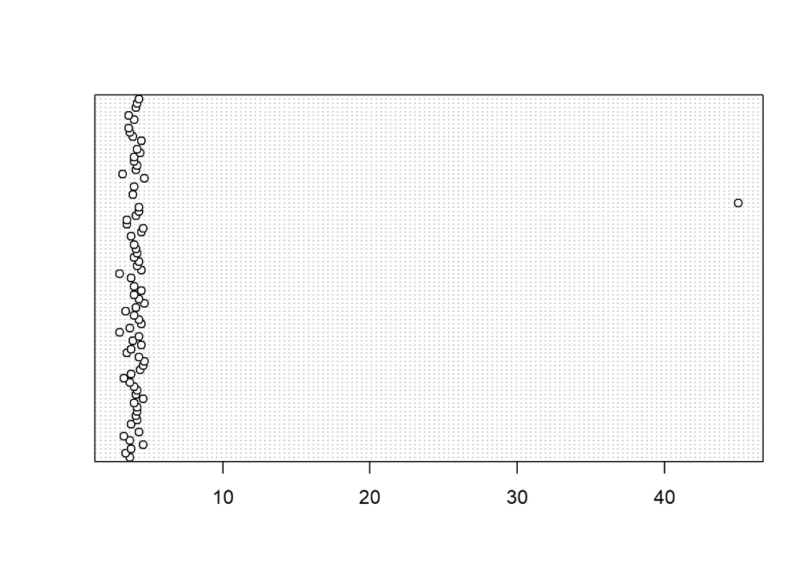

```
##   Respuesta         Enviado.el.    Q01_Genero Q02_FechaNac     Q03_Carrera
## 1      2494 26/02/2021 09:44:43 1 : Masculino   2002-11-23 3 : Estadística
##   Q04_Semestre Q05_Saber11 Q06_PercentilSaber11 Q07_FechaSaber11 Q08_PAPA
## 1            2         262                   63       2019-08-11       45
##   Q09_EnAreaMetropolitana Q10_Estrato Q11_R Q12_RStudio Q13_NoRoRStudio
## 1                       0       3 : 2     1           1
##   Q14_RecursosInformaticos..Internet.de.cable.propio
## 1                                                  1
##   Q14_RecursosInformaticos..Internet.de.cable.no.propio
## 1                                                     0
##   Q14_RecursosInformaticos..Wifi.propio
## 1                                     1
##   Q14_RecursosInformaticos..Wifi.no.propio
## 1                                        0
##   Q14_RecursosInformaticos..Celular.sin.datos
## 1                                           1
##   Q14_RecursosInformaticos..Celular.con.datos
## 1                                           0
##   Q14_RecursosInformaticos..Portátil.propio
## 1                                         1
##   Q14_RecursosInformaticos..Portátil.no.propio
## 1                                            0
##   Q14_RecursosInformaticos..Computador.de.escritorio.propio.y.exclusivo
## 1                                                                     0
##   Q14_RecursosInformaticos..Computador.de.escritorio.no.propio.pero.exclusivo
## 1                                                                           0
##   Q14_RecursosInformaticos..Computador.propio..pero.no.exclusivo
## 1                                                              0
##   Q14_RecursosInformaticos..Computador.de.escritorio.ni.propio.ni.exclusivo
## 1                                                                         0
##   Q14_RecursosInformaticos..Tablet.sin.datos
## 1                                          0
##   Q14_RecursosInformaticos..Tablet.con.datos. Q15_Alunizaje
## 1                                           0             1
##   Q16_EspionajeInternet Q17_Experimentos Q18_Vacunas Q19_EvidenciaFalsa
## 1                     1                1           0                  1
##   Q20_RafagasSolares Q21_TierraHueca Q22_alienigenas Q23_CambioClimatico
## 1                  0               0               0                   0
##   Q24_area Q25_PorcentArea Q26_Divisor..f.es.divisor.de.g.2.
## 1 4 : 4*pi              70                                 1
##   Q26_Divisor..f.es.divisor.de.gh. Q26_Divisor..f.es.divisor.de.h.g
## 1                                0                                1
##   Q27_PorcentDivisor     Edad       fecha_entrega tiempo_usado
## 1                 60 18.60096 2021-02-26 09:44:43     14.71667
```

```
##
##  1  2  3
## 39 28 20
```

```
##
##        1        2        3
## 44.82759 32.18391 22.98851
```

## Análisis univariado.

### Género.

```
##
## 1 : Masculino  2 : Femenino      3 : Otro
##            66            20             1
```

```
##
## 1 : Masculino  2 : Femenino      3 : Otro
##     75.862069     22.988506      1.149425
```

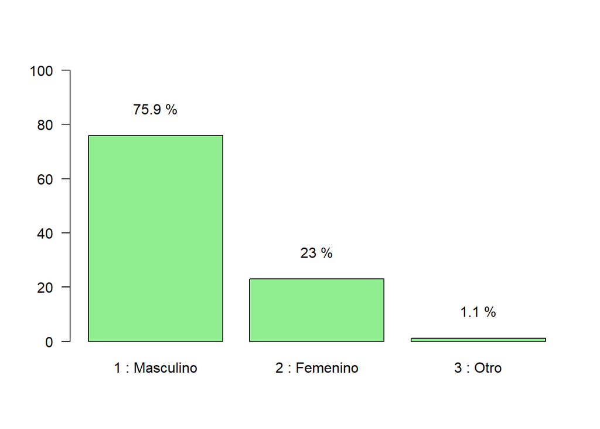

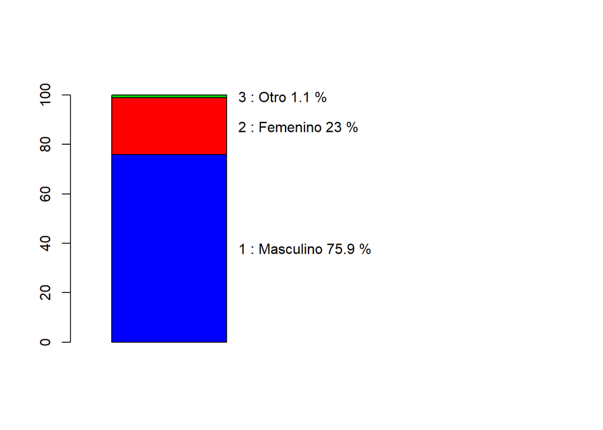

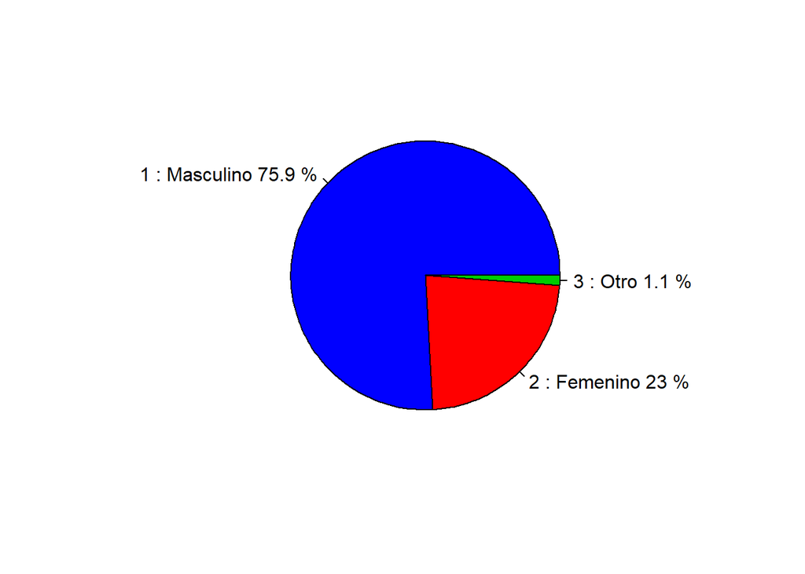

### Edad.

```
##    Min. 1st Qu.  Median    Mean 3rd Qu.    Max.
##   17.87   19.74   21.20   21.89   22.90   38.95
```

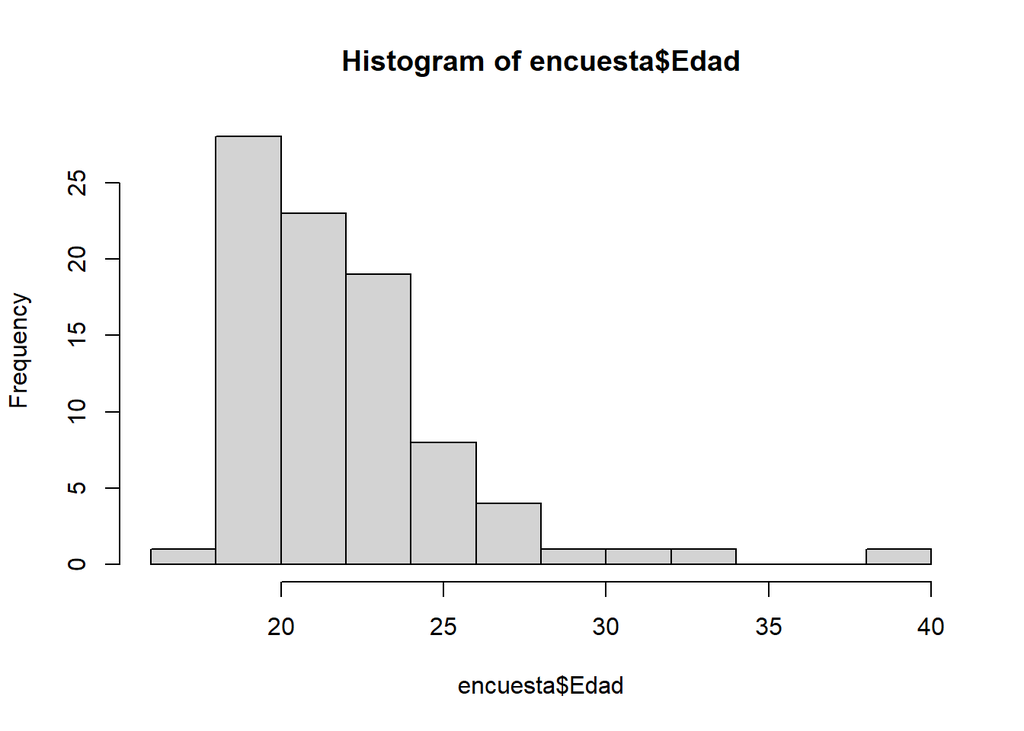

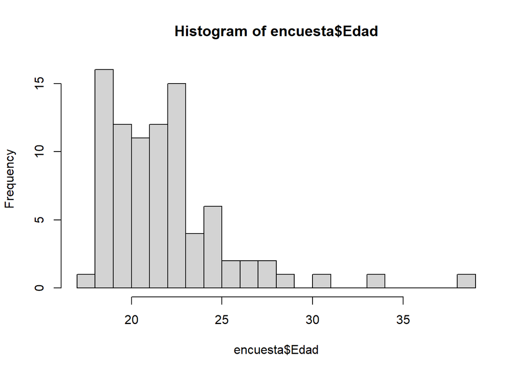

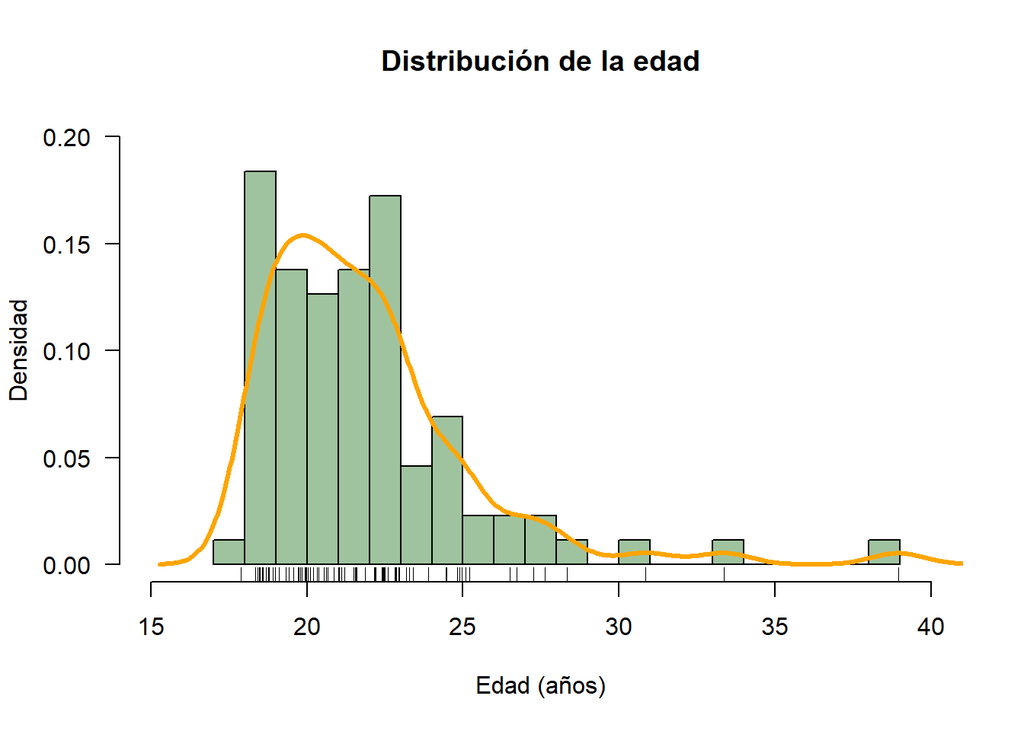

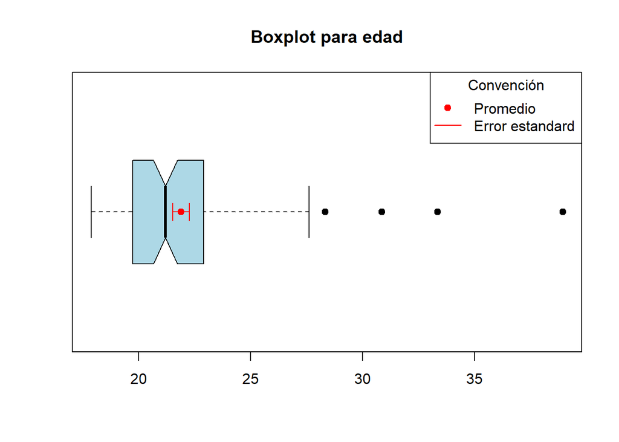

## Análisis bivariado.

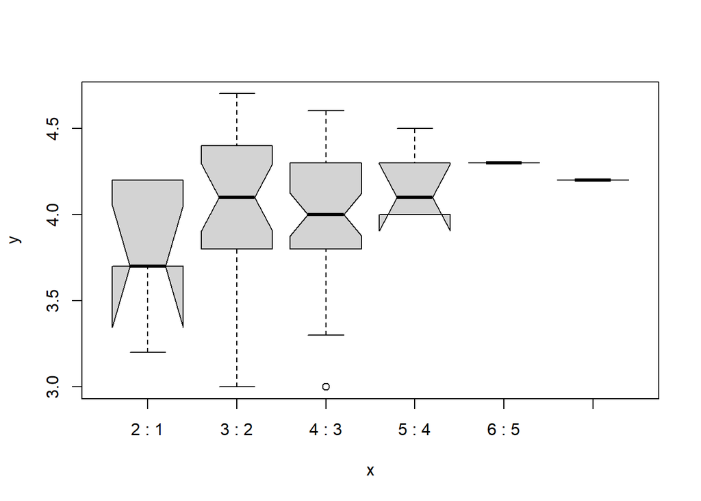

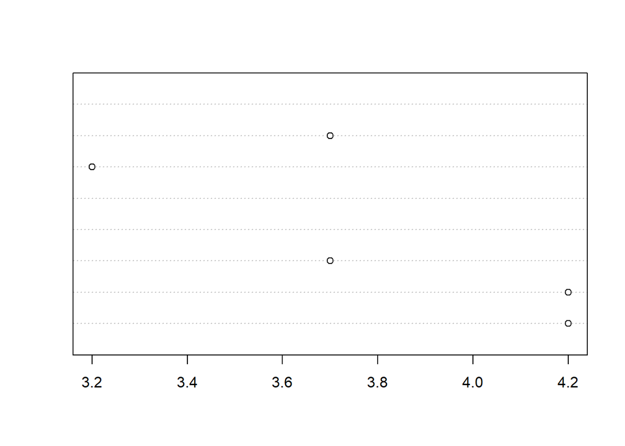

```
##    Min. 1st Qu.  Median    Mean 3rd Qu.    Max.    NA's
##     3.2     3.7     3.7     3.8     4.2     4.2       3
```

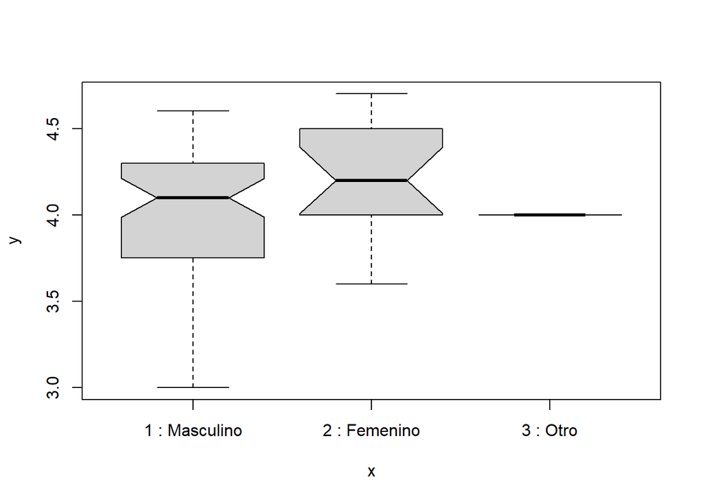

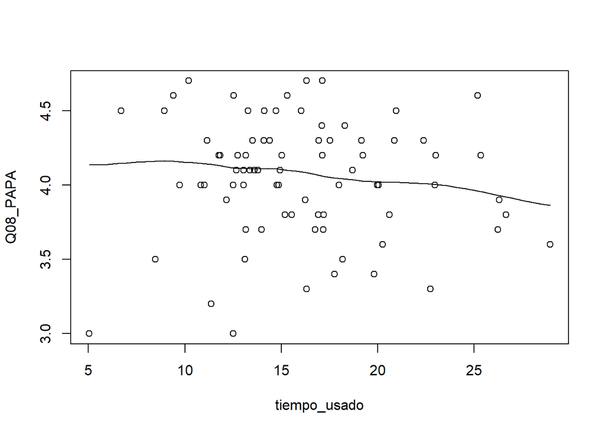

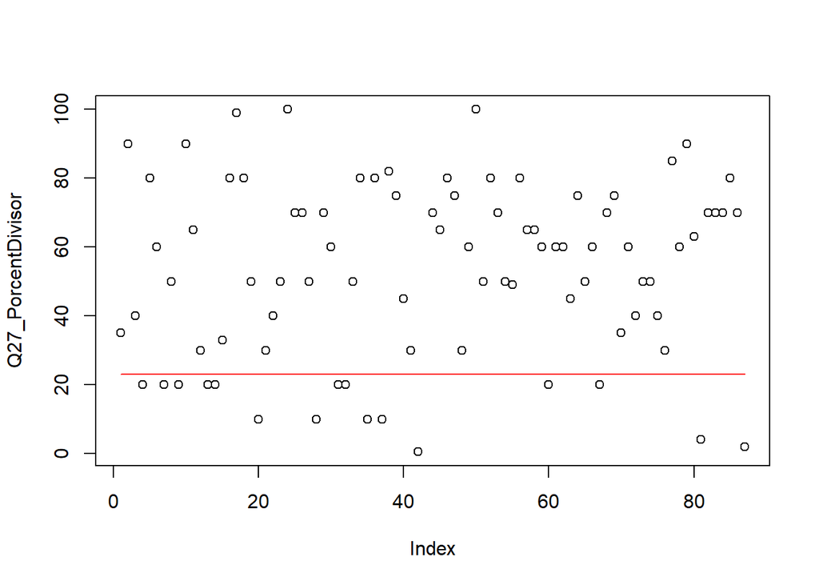

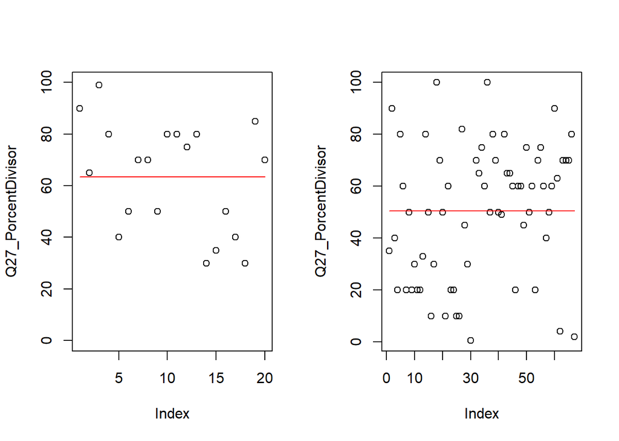

## Análisis multivariado.

Se considera que existe diferencia entre las carreras de sistemas y estadística en cuanto a los que tienen instalado tanto el R como el RStudio y que también al interior de cada carrera hay diferencias en los PAPA si se tiene en cuenta si ya tienen instalados o no el R y el RStudio.

Se piensa que los que tienen instalados ambos programas tienen un mejor desempeño académico en comparación con los que no lo hicieron.

También se cree que los estudiantes de estadística son los que en su mayoría han instalado el R y el RStudio.

### Resumen numérico

```
##                              Carrera_instala num_estud_carrera num_estud_noNA
## 1 2 : Ingeniería de sistemas e informática 0                26              1
## 2 2 : Ingeniería de sistemas e informática 2                26              1
## 3 2 : Ingeniería de sistemas e informática 3                26             24
## 4                          3 : Estadística 0                54              4
## 5                          3 : Estadística 1                54              3
## 6                          3 : Estadística 3                54             39
##   prom_PAPA desv_PAPA porcent_x_carrera
## 1  3.800000        NA          3.846154
## 2  3.800000        NA          3.846154
## 3  4.087500 0.3937694         92.307692
## 4  4.125000 0.3500000          7.407407
## 5  4.400000 0.2645751          5.555556
## 6  3.994872 0.4051957         72.222222
```

### Gráfica exploratoria.

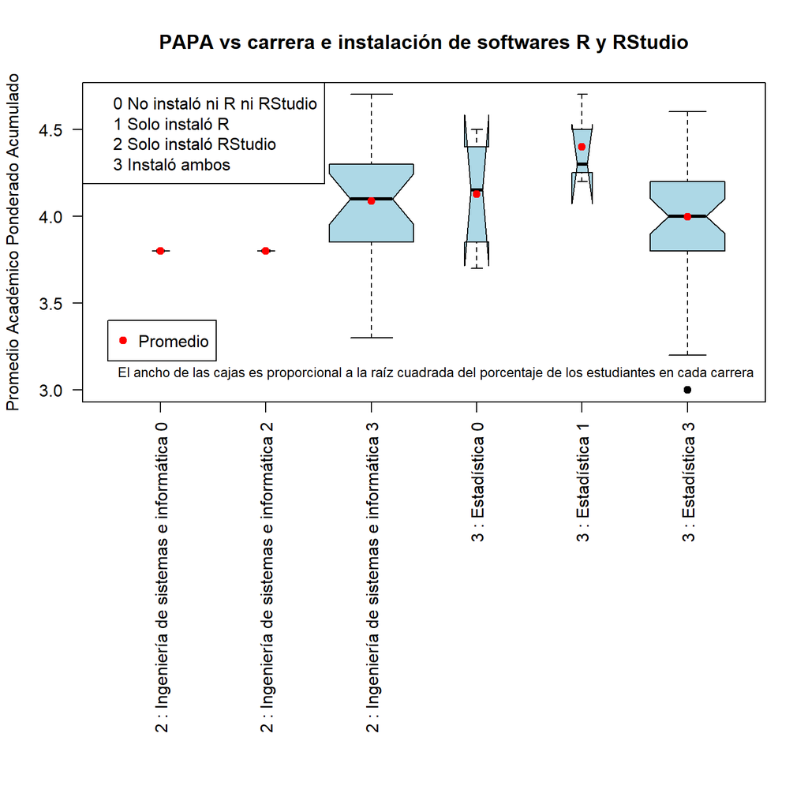

### Análisis.

Se observa que si consideramos a los estudiantes de Sistemas la mayoría han instalado el R y el RStudio (el 92.3%). Mientras que los de estadística solo el 72.2% lo han hecho. Esto es contrario a lo que se esperaba.

Se observa que el promedio y la mediana más alta en PAPA lo tienen los estudiantes de estadística que solo han instalado el R. Mientras que los promedios más bajos lo tienen los estudiantes de Sistemas que no han instalado el R o solo el RStudio.

Es importante anotar que en Sistemas solo uno no ha instalado los dos programas y solo uno ha instalado solo el RStudio. También es curioso que el de sistemas solo haya instalado el RStudio sin instalar el R.

Aparentemente los de estadística que solo han instalado el R tienen un buen desempeño académico.

Cabo anotar que no hay diferencia significativa en la medianas de los grupos porque los intervalos de confianza se superponen. Por lo tanto no se puede inferir que este comportamiento es generalizado.

Sorprende la tendencia del promedio y la mediana del grupo de estadística que han instalado los dos programas relativamente bajo, contrario a lo que se esperaba. Esto indica que posiblemente hayan otros factores que puedan estar asociado al desempeño académico y no solo el hecho de estar al día con la clase en cuanto a la instalación del software.

Se puede concluir que aunque no haya diferencia significativa entre los grupos si hay una tendencia a tener mejor desempeño en el el PAPA los estudiantes de estadística que tienen instalado solo el R, mientras que los que no lo han instalado los programas el desempeño académico tiene a se más bajo sin que haya diferencia significativa.